# A Quick Intro for R Beginners

```r
# We may also use the summary() function
summary(co2_df)
```

```
##  Country Code       Country Name          Region               Year
##  Length:11127       Length:11127       Length:11127       Min.   :1960
##  Class :character   Class :character   Class :character   1st Qu.:1973
##  Mode  :character   Mode  :character   Mode  :character   Median :1986
##                                                           Mean   :1986
##                                                           3rd Qu.:1998
##                                                           Max.   :2011
##
##     CO2 (kt)       CO2 Per Capita (metric tons)
##  Min.   :      4   Min.   : 0.0006
##  1st Qu.:    594   1st Qu.: 0.3490
##  Median :   4327   Median : 1.4506
##  Mean   :  98607   Mean   : 4.3408
##  3rd Qu.:  39924   3rd Qu.: 5.9532
##  Max.   :9019518   Max.   :99.8404
##  NA's   :2095      NA's   :2098
```

```r
# Now if we wanna make our columns names lower case and consists only of letters
# numbers and underscores
co2_df = clean_names(co2_df)

co2_df %>%
  group_by(country_name) %>%
  summarize(average_emissions = mean(co2_per_capita_metric_tons, na.rm = TRUE))
```

```
## # A tibble: 214 × 2
##    country_name        average_emissions
##    <chr>                           <dbl>
##  1 Afghanistan                     0.139
##  2 Albania                         1.66
##  3 Algeria                         2.39
##  4 American Samoa                NaN
##  5 Andorra                         6.93
##  6 Angola                          0.610
##  7 Antigua and Barbuda             5.11
##  8 Argentina                       3.56
##  9 Armenia                         1.23
## 10 Aruba                          21.8
## # … with 204 more rows
```

```r
# We can create a new column that's the sum of multiple columns as follows
co2_df = co2_df %>%
  mutate(
    'total' = rowSums(
                co2_df[,c('co2_per_capita_metric_tons', 'co2_kt')],
                na.rm = TRUE
              )
  )
head(co2_df)
```

```
## # A tibble: 6 × 7
##   country_code country_name region            year co2_kt co2_per_capita_… total
##   <chr>        <chr>        <chr>            <dbl>  <dbl>            <dbl> <dbl>
## 1 ABW          Aruba        Latin America &…  1960     NA               NA     0
## 2 ABW          Aruba        Latin America &…  1961     NA               NA     0
## 3 ABW          Aruba        Latin America &…  1962     NA               NA     0
## 4 ABW          Aruba        Latin America &…  1963     NA               NA     0
## 5 ABW          Aruba        Latin America &…  1964     NA               NA     0
## 6 ABW          Aruba        Latin America &…  1965     NA               NA     0
```

```r
# If we want to get the sum of each column separately
colSums(co2_df[,c('co2_per_capita_metric_tons', 'co2_kt')], na.rm = TRUE)
```

```
## co2_per_capita_metric_tons                     co2_kt
##                   39193.28               890622393.98
```

```r
# If we wanna merge multiple column into a single one
# Set remove to FALSE if you also wanna keep the original columns
co2_df = co2_df %>%
  unite(
    combined,
    c("country_name", "co2_per_capita_metric_tons", "year"),
    sep = "/"
  )
co2_df
```

```
## # A tibble: 11,127 × 5
##    country_code combined      region                    co2_kt total
##    <chr>        <chr>         <chr>                      <dbl> <dbl>
##  1 ABW          Aruba/NA/1960 Latin America & Caribbean     NA     0
##  2 ABW          Aruba/NA/1961 Latin America & Caribbean     NA     0
##  3 ABW          Aruba/NA/1962 Latin America & Caribbean     NA     0
##  4 ABW          Aruba/NA/1963 Latin America & Caribbean     NA     0
##  5 ABW          Aruba/NA/1964 Latin America & Caribbean     NA     0
##  6 ABW          Aruba/NA/1965 Latin America & Caribbean     NA     0
##  7 ABW          Aruba/NA/1966 Latin America & Caribbean     NA     0
##  8 ABW          Aruba/NA/1967 Latin America & Caribbean     NA     0
##  9 ABW          Aruba/NA/1968 Latin America & Caribbean     NA     0
## 10 ABW          Aruba/NA/1969 Latin America & Caribbean     NA     0
## # … with 11,117 more rows
```

```r
# Now let's do the reverse process
co2_df = co2_df %>%
  separate(
    combined,
    c("country_name", "co2_per_capita_metric_tons", "year"),
    sep = "/"
  )
co2_df
```

```
## # A tibble: 11,127 × 7
##    country_code country_name co2_per_capita_metric_to… year  region co2_kt total
##    <chr>        <chr>        <chr>                     <chr> <chr>   <dbl> <dbl>
##  1 ABW          Aruba        NA                        1960  Latin…     NA     0
##  2 ABW          Aruba        NA                        1961  Latin…     NA     0
##  3 ABW          Aruba        NA                        1962  Latin…     NA     0
##  4 ABW          Aruba        NA                        1963  Latin…     NA     0
##  5 ABW          Aruba        NA                        1964  Latin…     NA     0
##  6 ABW          Aruba        NA                        1965  Latin…     NA     0
##  7 ABW          Aruba        NA                        1966  Latin…     NA     0
##  8 ABW          Aruba        NA                        1967  Latin…     NA     0
##  9 ABW          Aruba        NA                        1968  Latin…     NA     0
## 10 ABW          Aruba        NA                        1969  Latin…     NA     0
## # … with 11,117 more rows
```

*To learn more about [Pivoting](https://tidyr.tidyverse.org/articles/pivot.html)*

```r
beachbugs_wide = read_csv('beachbugs_wide.csv')
head(beachbugs_wide)
```

```
## # A tibble: 6 × 12
##    year `Bondi Beach` `Bronte Beach` `Clovelly Beach` `Coogee Beach`
##   <dbl>         <dbl>          <dbl>            <dbl>          <dbl>
## 1  2013          32.2           26.8             9.28           39.7
## 2  2014          11.1           17.5            13.8            52.6
## 3  2015          14.3           23.6             8.82           40.3
## 4  2016          19.4           61.3            11.3            59.5
## 5  2017          13.2           16.8             7.93           20.7
## 6  2018          22.9           43.4            10.6            21.6
## # … with 7 more variables: `Gordons Bay (East)` <dbl>,
## #   `Little Bay Beach` <dbl>, `Malabar Beach` <dbl>, `Maroubra Beach` <dbl>,
## #   `South Maroubra Beach` <dbl>, `South Maroubra Rockpool` <dbl>,
## #   `Tamarama Beach` <dbl>
```

```r
bb_long = beachbugs_wide %>%
  pivot_longer(
    cols = colnames(beachbugs_wide)[2:12],
    names_to = 'beach',
    values_to = 'bugs'
  )
head(bb_long)
```

```
## # A tibble: 6 × 3
##    year beach                bugs
##   <dbl> <chr>               <dbl>
## 1  2013 Bondi Beach         32.2
## 2  2013 Bronte Beach        26.8
## 3  2013 Clovelly Beach       9.28
## 4  2013 Coogee Beach        39.7
## 5  2013 Gordons Bay (East)  24.8
## 6  2013 Little Bay Beach   122.
```

```r
beachbugs_long = read_csv("beachbugs_long.csv")
head(beachbugs_long)
```

```
## # A tibble: 6 × 3
##    year site               buglevels
##   <dbl> <chr>                  <dbl>
## 1  2013 Bondi Beach            32.2
## 2  2013 Bronte Beach           26.8
## 3  2013 Clovelly Beach          9.28
## 4  2013 Coogee Beach           39.7
## 5  2013 Gordons Bay (East)     24.8
## 6  2013 Little Bay Beach      122.
```

```r
bb_wide = beachbugs_long %>%
  pivot_wider(
    names_from = 'site',
    values_from = 'buglevels'
  )
head(bb_wide)
```

```
## # A tibble: 6 × 12
##    year `Bondi Beach` `Bronte Beach` `Clovelly Beach` `Coogee Beach`
##   <dbl>         <dbl>          <dbl>            <dbl>          <dbl>
## 1  2013          32.2           26.8             9.28           39.7
## 2  2014          11.1           17.5            13.8            52.6
## 3  2015          14.3           23.6             8.82           40.3
## 4  2016          19.4           61.3            11.3            59.5
## 5  2017          13.2           16.8             7.93           20.7
## 6  2018          22.9           43.4            10.6            21.6
## # … with 7 more variables: `Gordons Bay (East)` <dbl>,
## #   `Little Bay Beach` <dbl>, `Malabar Beach` <dbl>, `Maroubra Beach` <dbl>,
## #   `South Maroubra Beach` <dbl>, `South Maroubra Rockpool` <dbl>,
## #   `Tamarama Beach` <dbl>
```

### Note that every plot in the gglpot package must start with the ggplot()

### function where you specify the dataset.

Bar plots can be used to show the count of each categorical value in one variable only. If we want to used the bar plot for two variables, we use the column chart. However it’s better to use scatter plots and heat maps. Let’s try this simple column & scatter plots to see the difference.

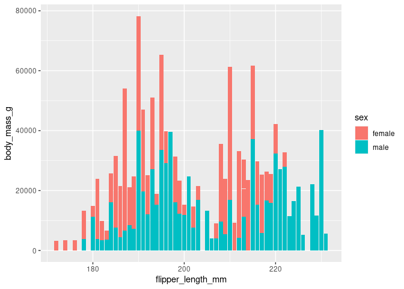

```r
ggplot(drop_na(penguins)) +
  geom_col(mapping = aes(flipper_length_mm, body_mass_g, fill = sex))
```

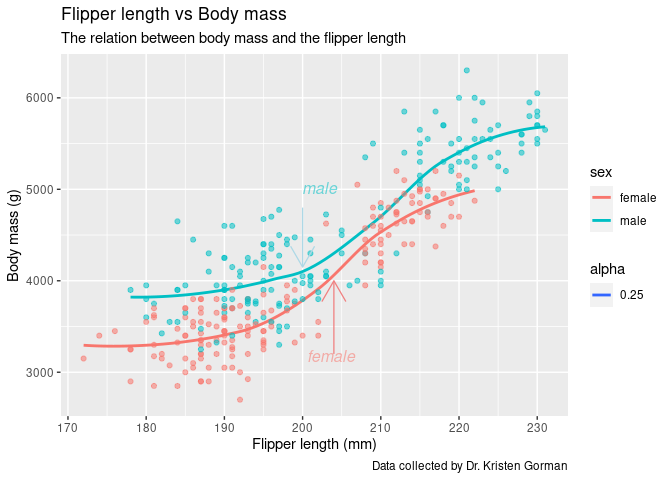

```r
ggplot(
  drop_na(penguins),
  # We may change the opaquity of the points using the alpha aesthetic to
  # be able to see whether if there're points plotted on top of each other
  # For instance, setting the alpha = 0.25 means that four points staked
  # on top of each other will create a solid point.
  aes(flipper_length_mm, body_mass_g, color = sex, alpha = 0.25)
) +
  # When plotting large number of points, it's quite useful to use geom_smooth
  # to clearly see the overall relationship between the variables.
  geom_smooth(se = FALSE) +
  geom_point(show.legend = FALSE) +
  # To apply labels inside the chart
  geom_dl(aes(label = sex, fontface = "italic"), method = "smart.grid") +
  # To add titles, subtitles, captions, y and x labels
  labs(
    title = "Flipper length vs Body mass",
    # Subtitles are usually used to highlight important information
    subtitle = "The relation between body mass and the flipper length",
    # Caption let us show the source of our data
    caption = "Data collected by Dr. Kristen Gorman",
    x = "Flipper length (mm)",
    y = "Body mass (g)"
  ) +
  # Another way to (manually) add the labels or create shapes
  annotate(
    geom = "segment",
    x = c(204, 200),
    xend = c(204, 200),
    y = c(3200, 4800),
    yend = c(4000, 4150),
    color = c("lightcoral", "lightblue"),
    size = c(0.45, 0.45),
    angle = c(90, 90),
    arrow = arrow()
  )
```

```r
# We may also use the geom_count to visualize the relationship between
# the flipper_length and the body_mass in addition to the frequency of
# value.

count_table = drop_na(penguins) %>%
  count(flipper_length_mm, body_mass_g)
count_table
```

```
## # A tibble: 298 × 3
##    flipper_length_mm body_mass_g     n
##                <int>       <int> <int>
##  1               172        3150     1
##  2               174        3400     1
##  3               176        3450     1
##  4               178        2900     1
##  5               178        3250     2
##  6               178        3900     1
##  7               180        3550     1
##  8               180        3600     1
##  9               180        3800     1
## 10               180        3950     1
## # … with 288 more rows
```

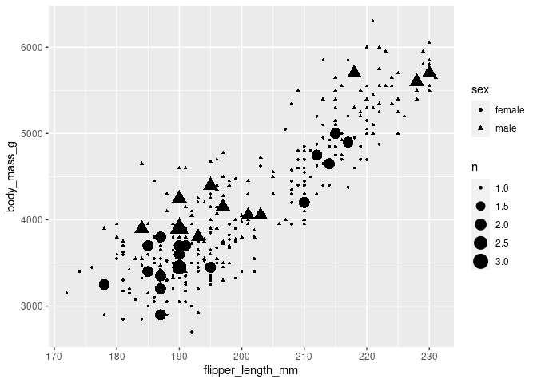

```r
ggplot(
  drop_na(penguins),
  aes(flipper_length_mm, body_mass_g, shape = sex)
) +
  geom_count()
```

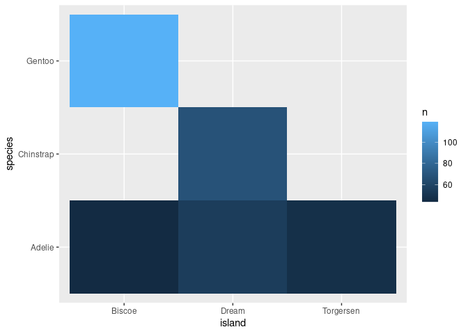

```r
drop_na(penguins) %>%
  count(island, species) %>%
  ggplot() +
  geom_tile(mapping = aes(island,species,fill = n))
```

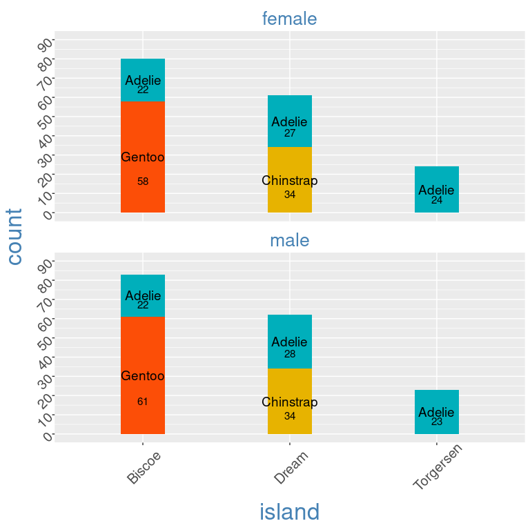

```r
ggplot(drop_na(penguins), aes(island, fill = species)) +
  geom_bar(show.legend = FALSE, width = 0.3, position = "stack") +
  # Select desired colors either by name or code
  scale_fill_manual(values = c("#00AFBB", "#E7B300", "#FC4E07")) +
  facet_wrap(sex ~ ., ncol = 1, strip.position = "top") +
  scale_y_continuous(limits = c(0, 90), n.breaks = 10) +
  theme(
    axis.text = element_text(size = 15, angle = 45),
    axis.text.x = element_text(vjust = 0.65),
    axis.title = element_text(size = 25, color = "steelblue"),
    strip.text = element_text(size = 20, color = "steelblue"),
    strip.background = element_blank()
  ) +
  # If we wanna to show label(s) on each bar
  stat_count(
    geom = "text",
    colour = "black",
    size = 5,
    aes(label = species),
    position = position_stack(vjust = 0.5)
  ) +
  stat_count(
    geom = "text",
    color = "black",
    size = 4,
    position = position_stack(vjust = 0.28),
    aes(label = ..count..)
  )
```

We may define Histograms as similar of barplots except they’re used for quantitative variables.

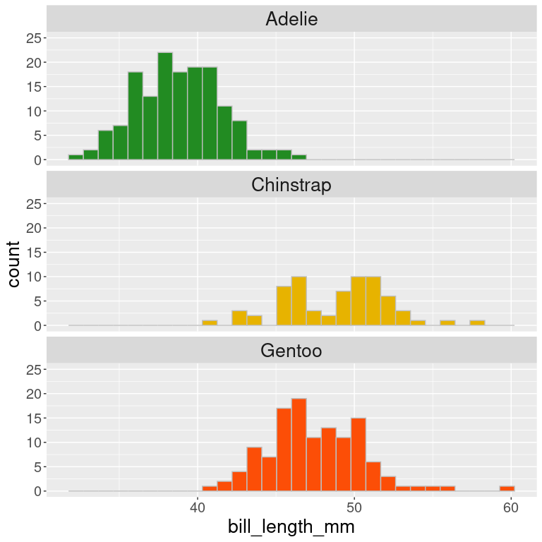

```r
ggplot(penguins, aes(bill_length_mm, fill = species)) +
  geom_histogram(show.legend = FALSE, col = 'grey') +
  scale_fill_manual(values = c("ForestGreen", "#E7B300", "#FC4E07")) +
  facet_wrap(species ~ ., strip.position = 'top', ncol = 1) +
  theme(
   axis.title = element_text(size = 20),
   strip.text = element_text(size = 20),
   axis.text = element_text(size = 15)
  ) +
  scale_y_continuous(limits = c(0,25))
```

```r
# To save the plot separately in a specific format
ggsave("penguins_2.png")
```

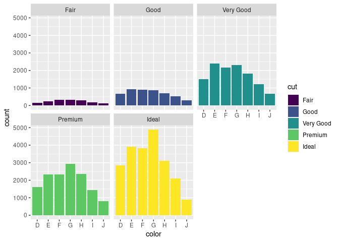

```r
# Another example
ggplot(data = diamonds) +
  geom_bar(mapping = aes(x = color, fill = cut)) +
  facet_wrap(.~cut)
```

There are three alternatives to the histogram as well

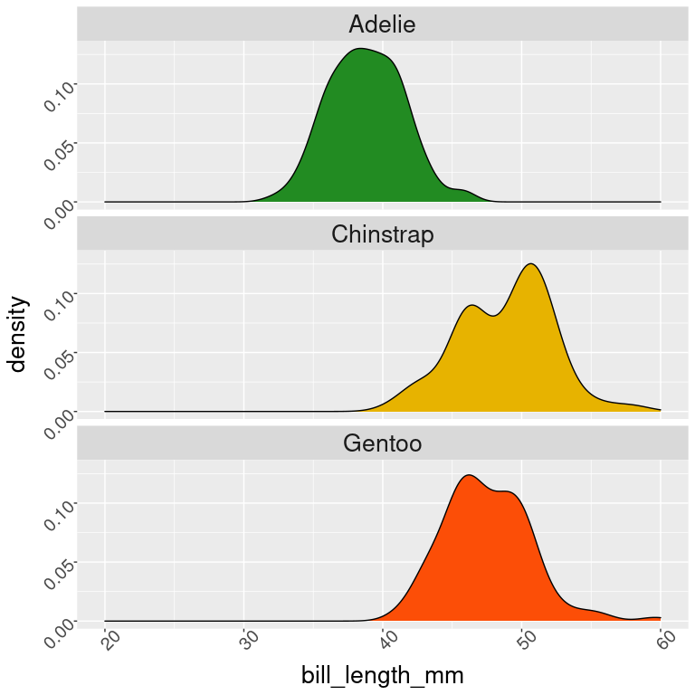

```r
# Density plot
ggplot(penguins, aes(bill_length_mm, fill = species)) +
  geom_density(show.legend = FALSE) +
  scale_fill_manual(values = c("ForestGreen", "#E7B300", "#FC4E07")) +
  facet_wrap(species ~ ., ncol = 1, strip.position = 'top') +
  scale_x_continuous(limits = c(20,60), n.breaks = 5) +
  theme(
   axis.text = element_text(size = 15, angle = 45),
   axis.title = element_text(size = 20),
   strip.text = element_text(size = 20)
  )
```

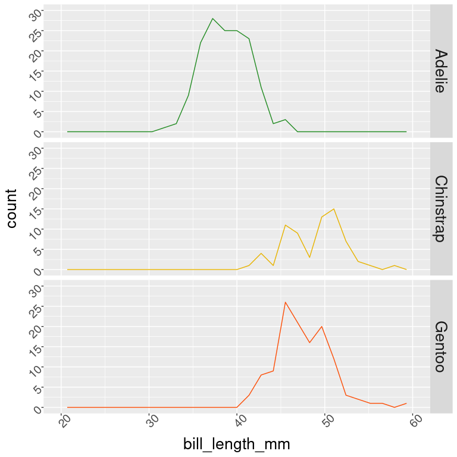

```r
# Frequency plot
ggplot(penguins, aes(bill_length_mm, color = species)) +
  geom_freqpoly(show.legend = FALSE) +
  scale_color_manual(values = c("ForestGreen", "#E7B300", "#FC4E07")) +
  facet_grid(species ~ .) +
  scale_x_continuous(limits = c(20,60), n.breaks = 5) +
  scale_y_continuous(limits = c(0,30), n.breaks = 6) +
  theme(
    axis.text = element_text(size = 15, angle = 45),
    axis.title = element_text(size = 20),
    strip.text = element_text(size = 20)
  )
```

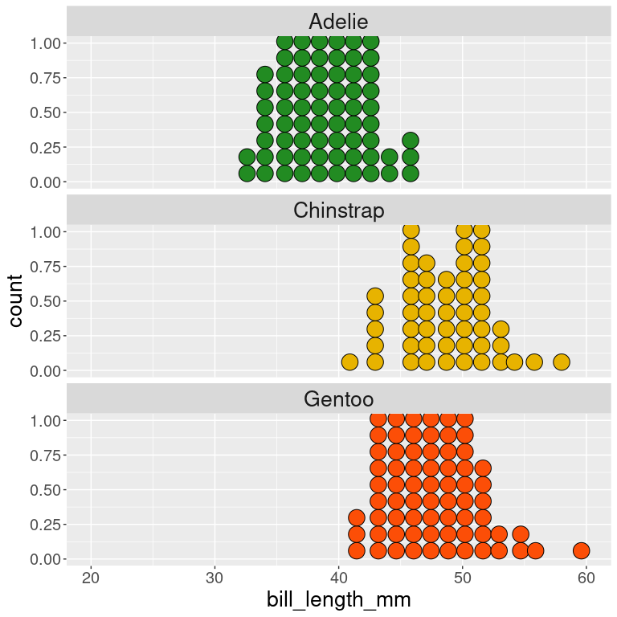

```r
# Dot plot
ggplot(penguins, aes(bill_length_mm, fill = species)) +
  geom_dotplot(show.legend = FALSE) +
  scale_fill_manual(values = c("ForestGreen", "#E7B300", "#FC4E07")) +
  facet_wrap(species ~ ., ncol = 1, strip.position = 'top') +
  scale_x_continuous(limits = c(20,60), n.breaks = 5) +
  theme(
    axis.title = element_text(size = 20),
    axis.text = element_text(size = 15),
    strip.text = element_text(size = 20)
  )
```

Now when working with Box plots, always keep in mind these two main notes: a) Box plots are usually used to plot qualitative vs. quantitative variables b) Any value > 1.5*IQR will be plotted as an outlier

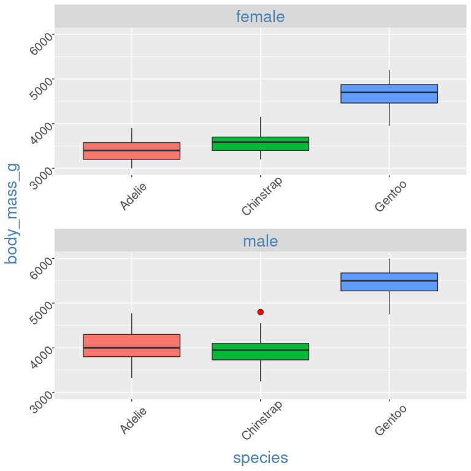

```r
ggplot(drop_na(penguins), aes(species, body_mass_g, fill = species)) +
  geom_boxplot(
      show.legend = FALSE,
      outlier.shape = 21, # A number 0:25 , NA will hide the outliers
      outlier.size = 3,
      outlier.fill = 'red'
  ) +
  facet_wrap(sex ~ ., scales = 'free_x', ncol = 1, strip.position = 'top') +
  scale_y_continuous(limits = c(2500,6500), n.breaks = 10)  +
  theme(
    axis.text = element_text(angle = 45, size = 15),
    axis.text.x = element_text(vjust = 0.65),
    axis.title = element_text(size = 20, color = 'steelblue'),
    strip.text = element_text(size = 20, color = 'steelblue')
  ) +
  ylim(3000, 6000) # To zoom in a specified portion of the plot (with clipping)
```

*Note that zoom with clipping removes the excluded point and recreate the plot*

Another similar plot is the violin plot. note how each violin shape gets thicker and thinner corresponding to the frequency of each value.

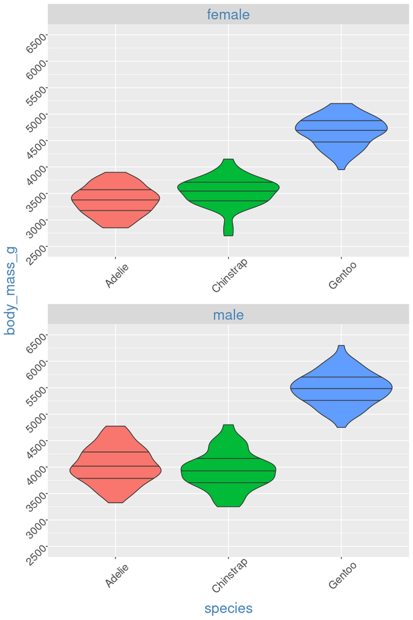

```r
ggplot(drop_na(penguins),aes(species, body_mass_g, fill = species)) +
  geom_violin(
      show.legend = FALSE,
      outlier.shape = 21, # A number 0:25 , NA will hide the outliers
      outlier.size = 3,
      outlier.fill = 'red',
      draw_quantiles = c(0.25, 0.5, 0.75)
  ) +
  facet_wrap(sex ~ ., scales = 'free_x', ncol = 1) +
  scale_y_continuous(limits = c(2000,7000), n.breaks = 10) +
  theme(
    axis.text = element_text(angle = 45, size = 15),
    axis.text.x = element_text(vjust = 0.65),
    axis.title = element_text(size = 20, color = 'steelblue'),
    strip.text = element_text(size = 20, color = 'steelblue')
  ) +
  # To zoom without clipping use coord_cartesian() as follows.
  coord_cartesian(ylim = c(2500, 6500))
```

If we want to plot two continuous variables using box plots. we may use cut_interval/cut_number/cut_width. Those cut functions basically group the values into a specified number of categories as shown below.

*Note: If we don’t wanna the source code to appear highlighted in the final rendered file, we set highlight = FALSE as shown below.*

```
penguins %>%
  ggplot(
    aes(
      flipper_length_mm,
      body_mass_g,
      group = cut_interval(flipper_length_mm, n = 4),
      fill = cut_interval(flipper_length_mm, n = 4),
    )
  ) +
  geom_boxplot(show.legend = FALSE) +
  scale_y_continuous(limits = c(2500, 6500), n.breaks = 20)
```

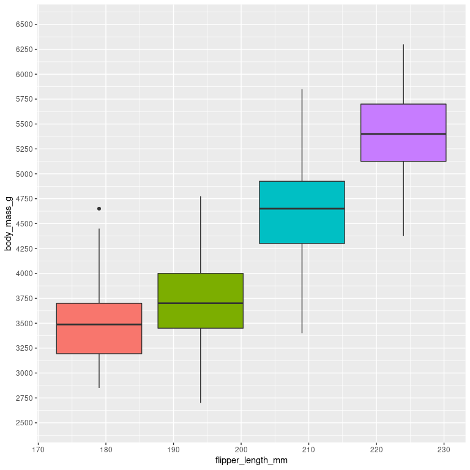

### Introduction to Rmarkdown

You may refer to the following [Link](https://www.coursera.org/learn/data-analysis-r/supplement/NSC0c/r-markdown-resources) for further resources.

```r
add a code block inside the text like this one using insert->code block
```

We may create the table like the one below using table shown in the top right.

This is a trial table

| First Name | Last Name | Email |
| --- | --- | --- |
| Aly | Kamel | aly.kamel@gmail.com |
| Mohamed | Mustafa | mo.mustafa@outlook.com |

  $$A = \pi * r^2$$

To add a horizontal ruler before or after a text just type (***)

> You may add a quote inside the text also by selecting the block quote symbol above.

An image can simply be inserted using the image symbol above

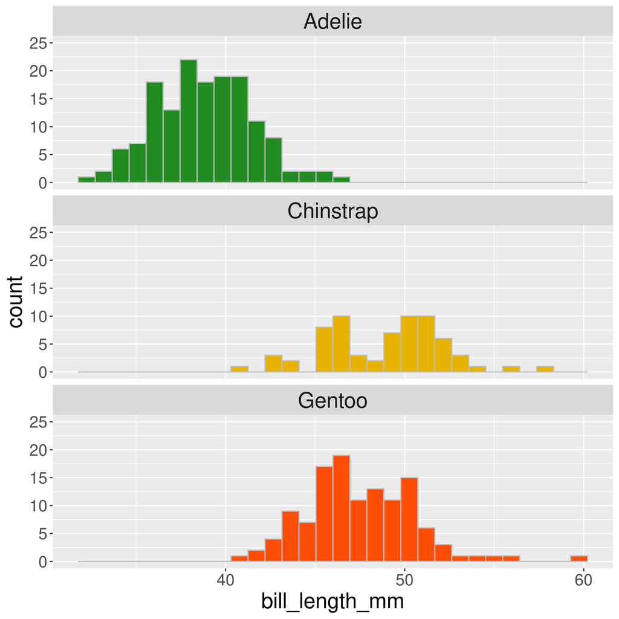

you may also add a caption to the image here

*You may create the below dashed line using (—) multiple times*

below are the main six types of fonts in the markdown files. you can choose any one of them either from the drop down list at the top right or using (ctrl + alt + (0:6))

# Heading_1

## Heading_2

### Heading_3

#### Heading_4

Normal Text

##### Heading_5

###### Heading_6

We may add definitions in our rmd files from the insert drop down list above

**RMD file**

R Markdown is a file format for making dynamic documents with R. An R Markdown document is written in markdown (an easy-to-write plain text format) and contains chunks of embedded R code.